# NY Times Article Search

Alice Friedman, DATA 607

October 26, 2018

# 1 Setup

```r
library(httr)
library(jsonlite)
library(dplyr)
library(ggplot2)
```

This code will not run without first obtaining an API Key from NYT.

Once acquired, save your API key to R using `Sys.setenv(NYTIMES_KEY="INSERT YOUR KEY HERE")`

Your key can be retrieved without revealing it through the R code by then using `Sys.getenv("NYTIMES_KEY")`

# 2 API structure

This API works by taking the base url “http://api.nytimes.com/svc/search/v2/articlesearch.json?q=” and searching based on certain parameters, which include:

- q (query term)
- begin_date (YYYYMMDD format for earliest date to search)
- end_date (YYYYMMDD format for latest date to search)
- fl (list of fields to return)

To search for specific fields for a specific query term or time, we must set parameters and then write a short piece of code which pastes those into a new URL.

## 2.1 Setting Parameters

```r
# Need to use + to string together separate words
q_term <- "dragons"
begin_date <- "201701011"
end_date <- "20180101"
```

## 2.2 Assembling the url and making the initial query

First, we paste our parameters together with the API key to develop the URI which will return a JSON response.

```r
baseurl <- paste0(
  "http://api.nytimes.com/svc/search/v2/articlesearch.json?q=",
  q_term,
  "&begin_date=",
  begin_date,
  "&end_date=",
  end_date,
  "&facet_filter=true&api-key=",
  Sys.getenv("NYTIMES_KEY"))

initialQuery <- fromJSON(baseurl)
```

# 3 Creating a function

To make this repeatable over different parameters, we can create a function to allow for a search of different search terms that will also:

- Convert results to a data frame
- Manipulate the search query to automatically download all pages of matching responses
- Merge the different responses into a single data frame.

Note: This function will still require an API key to function. To set yours, enter your key in the following code:

`Sys.setenv(NYTIMES_KEY="INSERT-YOUR-KEY-HERE")`

```r
articleSearch <- function(search_terms, search_from_date, search_to_date) {
  baseurl <- paste0(
      "http://api.nytimes.com/svc/search/v2/articlesearch.json?q=",
      search_terms,
      "&begin_date=",
      search_from_date,
      "&end_date=",
      search_to_date)
  initialQuery <- fromJSON(paste0(
    baseurl,
    "&facet_filter=true&api-key=",
    Sys.getenv("NYTIMES_KEY")))
  hits <- initialQuery$response$meta$hits
  numPages <- round((hits/10)-1)
  pages <- list()
#This Sys.sleep is very important--otherwise you will get a 429 error
  Sys.sleep(1)
  for(i in 0:numPages){
      nytSearch <- fromJSON(
        paste0(
          baseurl,
          "&page=",
          i,
          "&api-key=",
          Sys.getenv("NYTIMES_KEY")),
        flatten = TRUE) %>%
        data.frame()
      message("Retrieving page ", i)
      message(Sys.time())
      pages[[i+1]] <- nytSearch
      #A second Sys.sleep is needed in the for loop
      Sys.sleep(2)
  }
  allNYTSearch <- rbind_pages(pages)
}
```

## 3.1 Running the Function with Different Parameters

Let’s try running the function on a few different dessert trends and checking out some snippets.

```r
Sys.sleep(2)
cronuts2018 <- articleSearch("cronuts","20180101","20181027")
```

```
## Retrieving page 0
```

```
## 2018-10-27 22:44:25
```

```r
cronuts2018$response.docs.snippet[1:3]
```

```
## [1] "New Yorkers wait in line. Lots of lines. For anything. "
## [2] "For years, no chef dared try to improve the most iconic French pastry. Now, though, a new generation of bakers is trying."
## [3] "Two generations of bakers have made Alfonso’s Pastry Shoppe a reliable go-to for all kinds of cakes, and recent innovations have inspired foodie pilgrimages."
```

```r
Sys.sleep(2)
cupcakes2018 <- articleSearch("cupcakes","20180101","20181027")
```

```
## Retrieving page 0
```

```
## 2018-10-27 22:44:30
```

```
## Retrieving page 1
```

```
## 2018-10-27 22:44:32
```

```
## Retrieving page 2
```

```
## 2018-10-27 22:44:34
```

```
## Retrieving page 3
```

```
## 2018-10-27 22:44:37
```

```
## Retrieving page 4
```

```
## 2018-10-27 22:44:39
```

```
## Retrieving page 5
```

```
## 2018-10-27 22:44:41
```

```r
cupcakes2018$response.docs.snippet[1:3]
```

```
## [1] "Dogs, cops, cupcakes."
## [2] "The plot involves a team of covert agents devoted to a level of violence we’re told most people find unpalatable. Peter Berg directs."
## [3] "Contemporary art and vintage cars were on display at the September Art Fair in Bridgehampton, N.Y., as were plenty of early-fall looks. "
```

# 4 Visualizing the Data

To visualize the data, we will make a function that takes the search response data frame as an input.

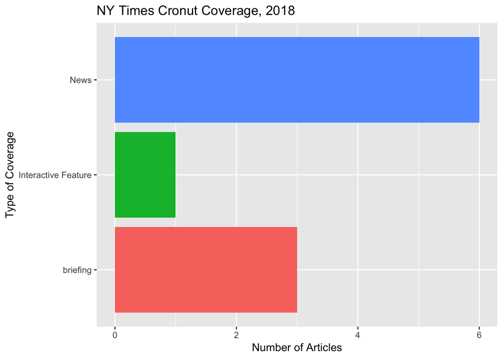

```r
#Create a function
sumBarChart <- function(dataframe) {
  dataframe %>%
  group_by(response.docs.type_of_material) %>%
  summarize(count=n()) %>%
  ggplot() +
    geom_bar(aes(y=count,
               x=response.docs.type_of_material,
               fill=response.docs.type_of_material),
           stat = "identity") +
    coord_flip() +
    labs(y="Number of Articles", x="Type of Coverage")+
    theme(legend.position="none")
}

sumBarChart(cronuts2018)+ggtitle("NY Times Cronut Coverage, 2018")
```

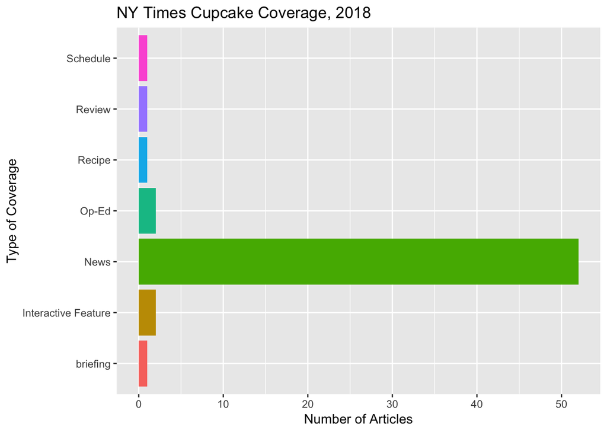

```r
sumBarChart(cupcakes2018)+ggtitle("NY Times Cupcake Coverage, 2018")
```

Looks like cupcakes were a lot more popular in 2018 than cronuts!

# 5 References

The above code is heavily indebted to the work of Jonathan D. Fitzgerald, published on January 25, 2018 on [*Storybench*](http://www.storybench.org/), [“Working with The New York Times API in R”](http://www.storybench.org/working-with-the-new-york-times-api-in-r/)